# Background

Using devices such as Jawbone Up, Nike FuelBand, and Fitbit it is now possible to collect a large amount of data about personal activity relatively inexpensively. These type of devices are part of the quantified self movement - a group of enthusiasts who take measurements about themselves regularly to improve their health, to find patterns in their behavior, or because they are tech geeks. One thing that people regularly do is quantify how much of a particular activity they do, but they rarely quantify how well they do it. In this project, your goal will be to use data from accelerometers on the belt, forearm, arm, and dumbell of 6 participants. They were asked to perform barbell lifts correctly and incorrectly in 5 different ways. More information is available from the website here: http://groupware.les.inf.puc-rio.br/har (see the section on the Weight Lifting Exercise Dataset).

# Data

The training data for this project are available here: https://d396qusza40orc.cloudfront.net/predmachlearn/pml-training.csv

The test data are available here: https://d396qusza40orc.cloudfront.net/predmachlearn/pml-testing.csv

The data for this project come from this source: http://groupware.les.inf.puc-rio.br/har.

```r
library(caret)
```

```r
#setwd(".\\PML\\Project")
fileName = "pml-training.csv"
url = "https://d396qusza40orc.cloudfront.net/predmachlearn/pml-training.csv"
if (!file.exists(fileName)) { download.file(url, fileName) }
actDF = read.csv(fileName)
```

We will split data into training, testing and validation sets.

```r
set.seed(123)
inTrain = createDataPartition(actDF$classe, p = 0.6, list = FALSE)
train = actDF[inTrain, ]
inTest = createDataPartition(actDF[-inTrain, ]$classe, p = 0.5, list = FALSE)
test = actDF[-inTrain, ][inTest, ]
valid = actDF[-inTrain, ][-inTest, ]
```

# Preprocess

There are many variates that have more than 50% missing or empty values. We will go ahead and drop these variates because they will likely trip the machine learning algorithms.

```r
# drop NA variants
na = integer()
for (i in 1:ncol(train)) {
        ratio = sum(is.na(train[, i])) / nrow(train)
        if (ratio > 0.5) { na = c(na, i) }
}
train = train[, -c(na)]

# drop empty variants
empty = integer()
for (i in 1:ncol(train)) {
        ratio = sum(train[, i] == "") / nrow(train)
        if (ratio > 0.50) { empty = c(empty, i) }
}
train = train[, -c(empty)]
```

There are many variates that are the transformations of the true signals. The following are some of these variates: min, max, average, variance, standard deviation. By dropping these variates, we are not losing valuable information. Therefore, let’s only pick the accelerometer measurements.

```r
# pick accelerometer measurements
forearm = grep("_forearm", names(train))
belt = grep("_belt", names(train))
dumbbell = grep("_dumbbell", names(train))
arm = grep("_arm", names(train))
train = cbind(train[, arm], train[, forearm], train[, belt], train[, dumbbell], classe = train[, "classe"])
```

# Train Model

We’ll use one of the most widely used classifier, Random Forest, with 10 fold of cross validations. The output is modeled with all the remaining covariates. Since several of the variants are highly skewed and/or have kurtosis (taller peak than normal distribution), we should use the Box Cox transformation. We should also run PCA to compress the features.

```r
fit.rf    = train(train$classe ~ ., data = train, method = "rf",    preProcess = c("pca", "BoxCox"), trControl = trainControl(method = "cv"))
```

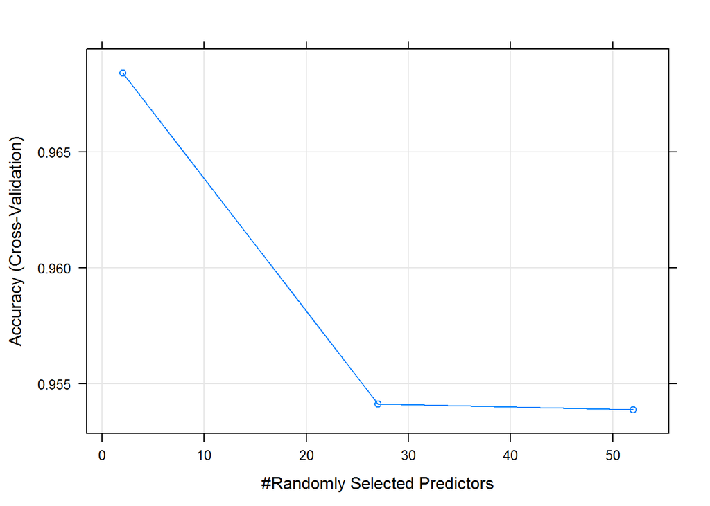

```r
plot(fit.rf)
```

```r
fit.rf$finalModel
```

```
##
## Call:
##  randomForest(x = x, y = y, mtry = param$mtry)
##                Type of random forest: classification
##                      Number of trees: 500
## No. of variables tried at each split: 2
##
##         OOB estimate of  error rate: 3%
## Confusion matrix:
##      A    B    C    D    E class.error
## A 3315   12   10    7    4 0.009856631
## B   42 2178   49    3    7 0.044317683
## C    5   34 1988   25    2 0.032132425
## D    4    3   90 1833    0 0.050259067
## E    4   16   20   16 2109 0.025866051
```

Also, as we can see the OOB error rate is 3%.

# Test Prediction

Let’s run our model on the test set.

```r
pred.rf = predict(fit.rf, test)

# confusion matrix on test
cmx.rf = confusionMatrix(pred.rf, test$classe)
cmx.rf
```

```
## Confusion Matrix and Statistics
##
##           Reference
## Prediction    A    B    C    D    E
##          A 1104   12    2    4    0
##          B    3  732   12    1    4
##          C    4   14  659   24    6
##          D    3    0    9  613    5
##          E    2    1    2    1  706
##
## Overall Statistics
##
##                Accuracy : 0.9722
##                  95% CI : (0.9666, 0.9771)
##     No Information Rate : 0.2845
##     P-Value [Acc > NIR] : < 2e-16
##
##                   Kappa : 0.9648
##  Mcnemar's Test P-Value : 0.01212
##
## Statistics by Class:
##
##                      Class: A Class: B Class: C Class: D Class: E
## Sensitivity            0.9892   0.9644   0.9635   0.9533   0.9792
## Specificity            0.9936   0.9937   0.9852   0.9948   0.9981
## Pos Pred Value         0.9840   0.9734   0.9321   0.9730   0.9916
## Neg Pred Value         0.9957   0.9915   0.9922   0.9909   0.9953
## Prevalence             0.2845   0.1935   0.1744   0.1639   0.1838
## Detection Rate         0.2814   0.1866   0.1680   0.1563   0.1800
## Detection Prevalence   0.2860   0.1917   0.1802   0.1606   0.1815
## Balanced Accuracy      0.9914   0.9791   0.9743   0.9741   0.9887
```

Above, the Kappa value is 0.96 which is the accuracy measurement for multiclass problem.

# Validation Prediction

```r
pred.valid.rf = predict(fit.rf, valid)

# confusion matrix on validation
cmx.valid.rf = confusionMatrix(pred.valid.rf, valid$classe)
cmx.valid.rf
```

```
## Confusion Matrix and Statistics
##
##           Reference
## Prediction    A    B    C    D    E
##          A 1103    7    1    1    1
##          B    3  732   12    1    2
##          C    4   17  669   29    5
##          D    3    0    2  609    6
##          E    3    3    0    3  707
##
## Overall Statistics
##
##                Accuracy : 0.9737
##                  95% CI : (0.9682, 0.9785)
##     No Information Rate : 0.2845
##     P-Value [Acc > NIR] : < 2.2e-16
##
##                   Kappa : 0.9668
##  Mcnemar's Test P-Value : 5.709e-05
##
## Statistics by Class:
##
##                      Class: A Class: B Class: C Class: D Class: E
## Sensitivity            0.9884   0.9644   0.9781   0.9471   0.9806
## Specificity            0.9964   0.9943   0.9830   0.9966   0.9972
## Pos Pred Value         0.9910   0.9760   0.9240   0.9823   0.9874
## Neg Pred Value         0.9954   0.9915   0.9953   0.9897   0.9956
## Prevalence             0.2845   0.1935   0.1744   0.1639   0.1838
## Detection Rate         0.2812   0.1866   0.1705   0.1552   0.1802
## Detection Prevalence   0.2837   0.1912   0.1846   0.1580   0.1825
## Balanced Accuracy      0.9924   0.9794   0.9805   0.9719   0.9889
```

# plots

```r
summary(train)
```

```
##     roll_arm         pitch_arm          yaw_arm           total_accel_arm
##  Min.   :-180.00   Min.   :-87.900   Min.   :-180.00000   Min.   : 1.00
##  1st Qu.: -32.83   1st Qu.:-25.800   1st Qu.: -41.40000   1st Qu.:17.00
##  Median :   0.00   Median :  0.000   Median :   0.00000   Median :27.00
##  Mean   :  17.26   Mean   : -4.691   Mean   :   0.05521   Mean   :25.54
##  3rd Qu.:  76.50   3rd Qu.: 11.100   3rd Qu.:  46.30000   3rd Qu.:33.00
##  Max.   : 180.00   Max.   : 88.500   Max.   : 180.00000   Max.   :65.00
##   gyros_arm_x        gyros_arm_y       gyros_arm_z       accel_arm_x
##  Min.   :-6.37000   Min.   :-3.4400   Min.   :-2.2800   Min.   :-404.00
##  1st Qu.:-1.32000   1st Qu.:-0.8000   1st Qu.:-0.0700   1st Qu.:-242.00
##  Median : 0.08000   Median :-0.2400   Median : 0.2300   Median : -46.00
##  Mean   : 0.04313   Mean   :-0.2577   Mean   : 0.2701   Mean   : -61.11
##  3rd Qu.: 1.56000   3rd Qu.: 0.1300   3rd Qu.: 0.7200   3rd Qu.:  83.00
##  Max.   : 4.82000   Max.   : 2.8100   Max.   : 3.0200   Max.   : 437.00
##   accel_arm_y       accel_arm_z      magnet_arm_x     magnet_arm_y
##  Min.   :-318.00   Min.   :-630.0   Min.   :-580.0   Min.   :-386.0
##  1st Qu.: -55.00   1st Qu.:-142.2   1st Qu.:-303.0   1st Qu.:  -9.0
##  Median :  12.00   Median : -49.0   Median : 283.0   Median : 201.0
##  Mean   :  32.25   Mean   : -71.9   Mean   : 190.8   Mean   : 156.6
##  3rd Qu.: 140.00   3rd Qu.:  22.0   3rd Qu.: 641.0   3rd Qu.: 323.0
##  Max.   : 299.00   Max.   : 292.0   Max.   : 780.0   Max.   : 582.0
##   magnet_arm_z     roll_forearm       pitch_forearm      yaw_forearm
##  Min.   :-595.0   Min.   :-180.0000   Min.   :-72.500   Min.   :-180.00
##  1st Qu.: 129.0   1st Qu.:  -0.3525   1st Qu.:  0.000   1st Qu.: -66.70
##  Median : 444.0   Median :  22.4000   Median :  8.985   Median :   0.00
##  Mean   : 306.6   Mean   :  34.1348   Mean   : 10.539   Mean   :  19.89
##  3rd Qu.: 545.0   3rd Qu.: 140.0000   3rd Qu.: 28.000   3rd Qu.: 110.00
##  Max.   : 694.0   Max.   : 180.0000   Max.   : 89.800   Max.   : 180.00
##  total_accel_forearm gyros_forearm_x    gyros_forearm_y
##  Min.   :  0.00      Min.   :-22.0000   Min.   : -7.02000
##  1st Qu.: 29.00      1st Qu.: -0.2100   1st Qu.: -1.46000
##  Median : 36.00      Median :  0.0500   Median :  0.03000
##  Mean   : 34.68      Mean   :  0.1604   Mean   :  0.08768
##  3rd Qu.: 41.00      3rd Qu.:  0.5600   3rd Qu.:  1.61000
##  Max.   :108.00      Max.   :  3.4800   Max.   :311.00000
##  gyros_forearm_z    accel_forearm_x  accel_forearm_y   accel_forearm_z
##  Min.   : -8.0900   Min.   :-498.0   Min.   :-632.00   Min.   :-391.00
##  1st Qu.: -0.1800   1st Qu.:-178.0   1st Qu.:  59.75   1st Qu.:-181.00
##  Median :  0.0800   Median : -57.0   Median : 201.00   Median : -38.00
##  Mean   :  0.1618   Mean   : -61.6   Mean   : 164.44   Mean   : -54.35
```

[output cut: 43 more lines]

```
##  Max.   :58.00        Max.   :   2.2200   Max.   :52.00000
##  gyros_dumbbell_z   accel_dumbbell_x  accel_dumbbell_y  accel_dumbbell_z
##  Min.   : -2.3800   Min.   :-419.00   Min.   :-189.00   Min.   :-334.00
##  1st Qu.: -0.3100   1st Qu.: -51.00   1st Qu.:  -8.00   1st Qu.:-142.00
##  Median : -0.1300   Median :  -8.00   Median :  41.00   Median :  -1.00
##  Mean   : -0.1159   Mean   : -28.68   Mean   :  52.68   Mean   : -38.67
##  3rd Qu.:  0.0300   3rd Qu.:  11.00   3rd Qu.: 111.00   3rd Qu.:  37.00
##  Max.   :317.0000   Max.   : 235.00   Max.   : 302.00   Max.   : 318.00
##  magnet_dumbbell_x magnet_dumbbell_y magnet_dumbbell_z classe
##  Min.   :-639      Min.   :-742.0    Min.   :-249.00   A:3348
##  1st Qu.:-536      1st Qu.: 232.0    1st Qu.: -45.00   B:2279
##  Median :-479      Median : 311.0    Median :  13.00   C:2054
##  Mean   :-330      Mean   : 223.4    Mean   :  46.58   D:1930
##  3rd Qu.:-307      3rd Qu.: 390.0    3rd Qu.:  95.25   E:2165
##  Max.   : 584      Max.   : 633.0    Max.   : 452.00
```

```r
table(train$classe)
```

```
##
##    A    B    C    D    E
## 3348 2279 2054 1930 2165
```

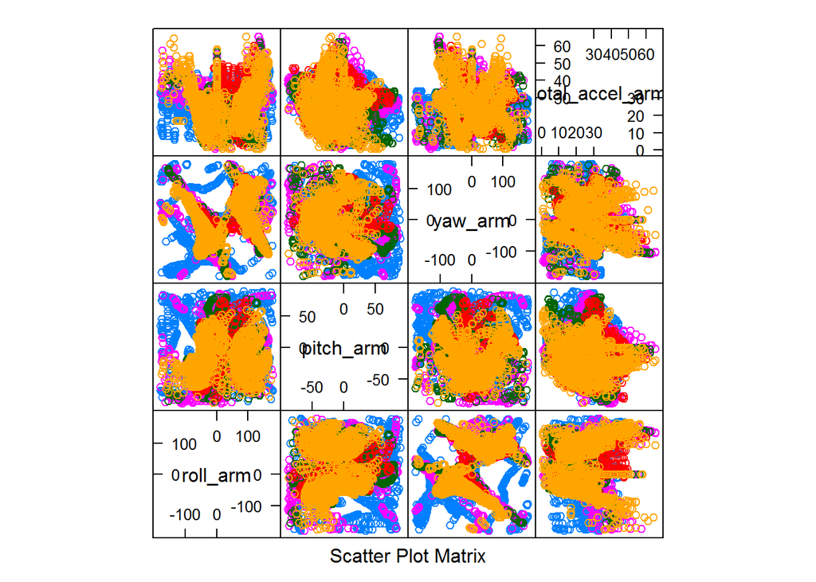

```r
x = subset(train, select = c(
        roll_arm,      pitch_arm,      yaw_arm,      total_accel_arm,
        roll_forearm,  pitch_forearm,  yaw_forearm,  total_accel_forearm,
        roll_belt,     pitch_belt,     yaw_belt,     total_accel_belt,
        roll_dumbbell, pitch_dumbbell, yaw_dumbbell, total_accel_dumbbell,
        classe))
attach(x)
featurePlot(x[, c("roll_arm", "pitch_arm", "yaw_arm", "total_accel_arm" )], classe, plot = "pairs")
```

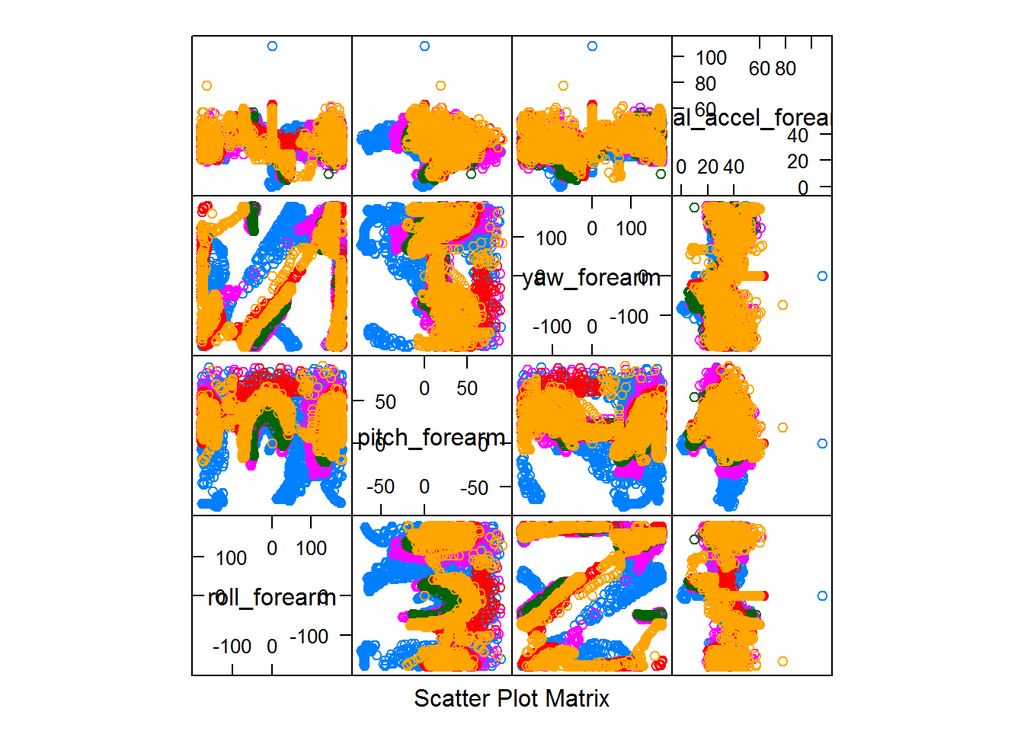

```r
featurePlot(x[, c("roll_forearm", "pitch_forearm", "yaw_forearm", "total_accel_forearm" )], classe, plot = "pairs")
```

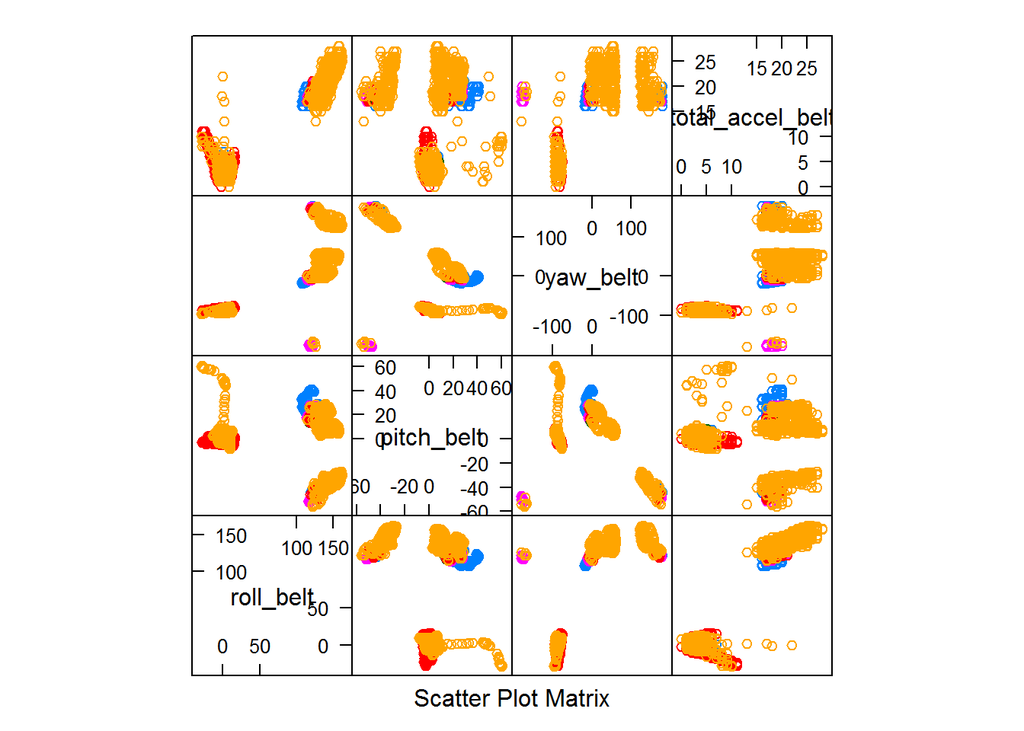

```r
featurePlot(x[, c("roll_belt", "pitch_belt", "yaw_belt", "total_accel_belt" )], classe, plot = "pairs")
```

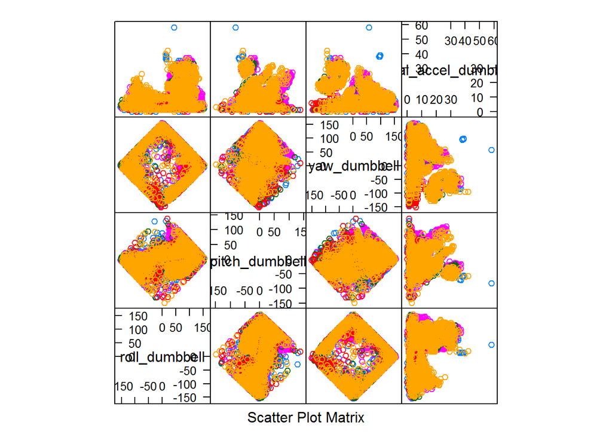

```r
featurePlot(x[, c("roll_dumbbell", "pitch_dumbbell", "yaw_dumbbell", "total_accel_dumbbell" )], classe, plot = "pairs")
```

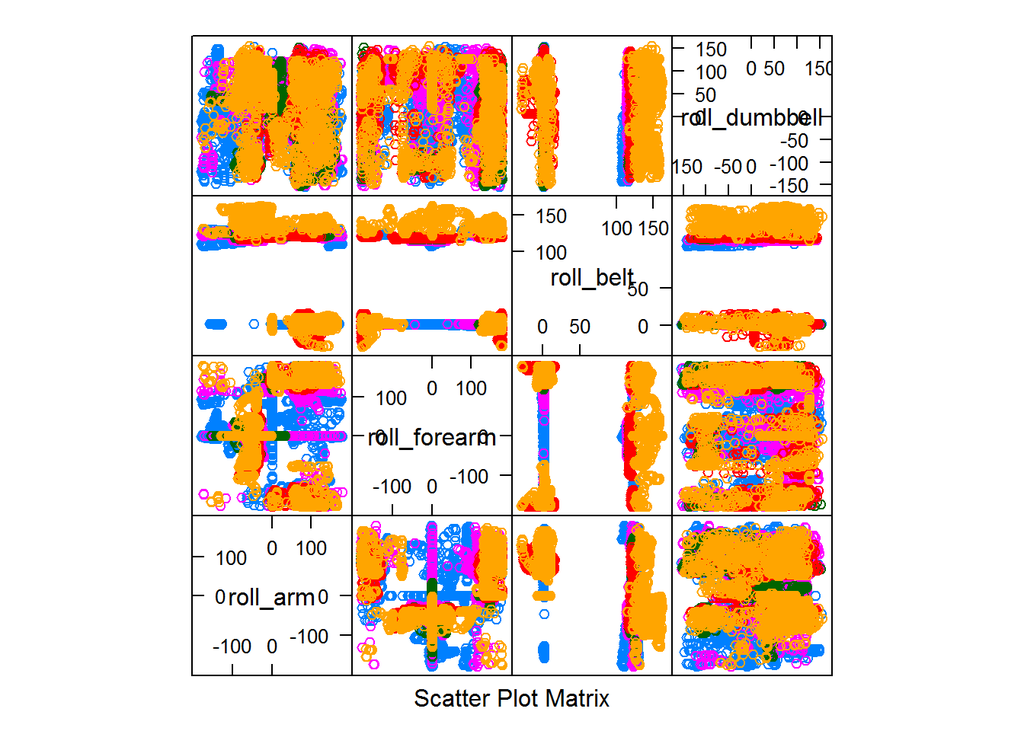

```r
featurePlot(x[, c("roll_arm", "roll_forearm", "roll_belt", "roll_dumbbell" )], classe, plot = "pairs")
```

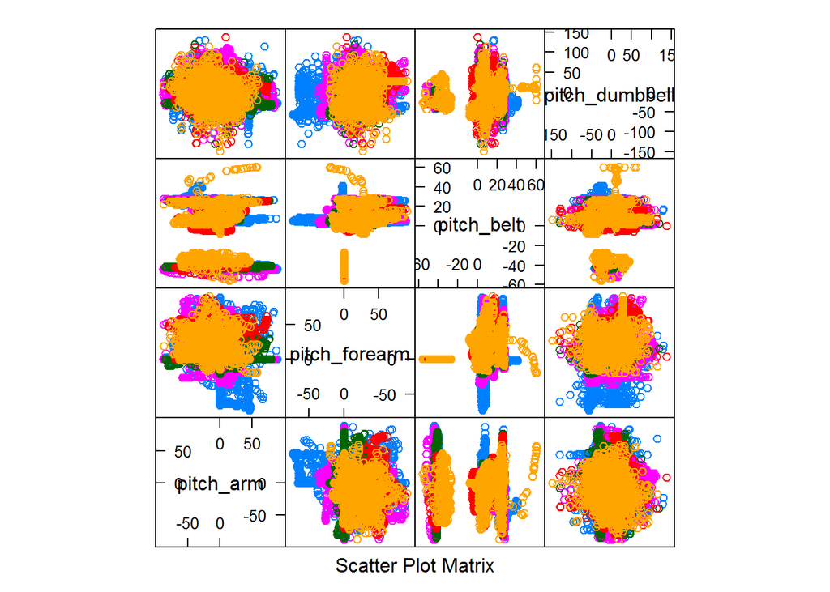

```r
featurePlot(x[, c("pitch_arm", "pitch_forearm", "pitch_belt", "pitch_dumbbell" )], classe, plot = "pairs")
```

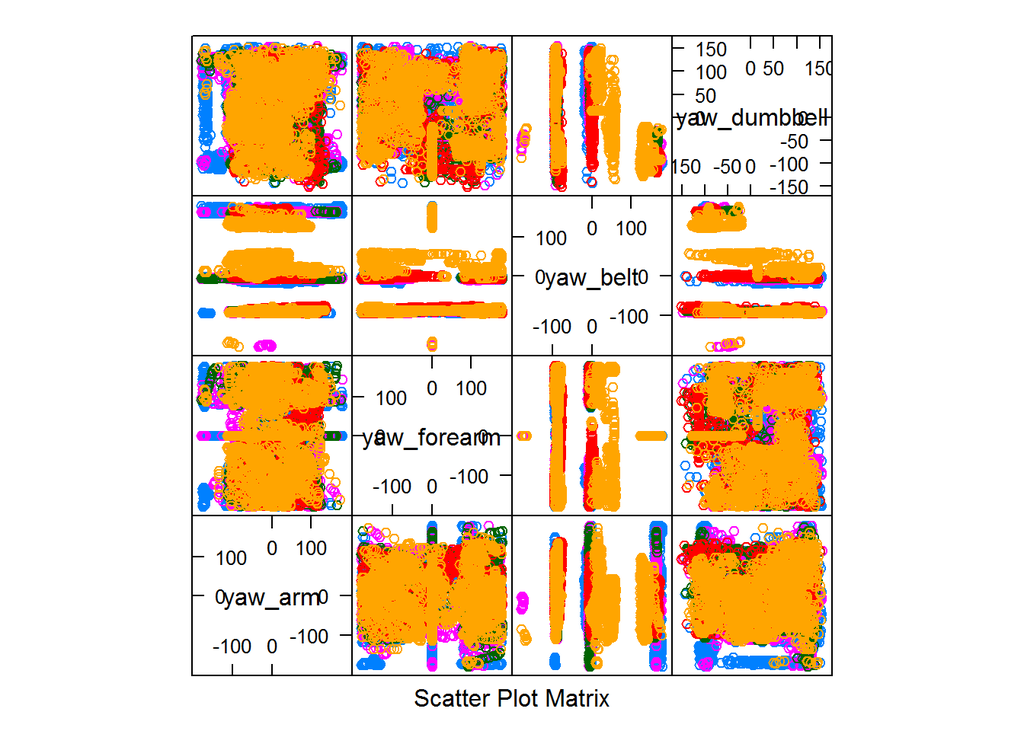

```r
featurePlot(x[, c("yaw_arm", "yaw_forearm", "yaw_belt", "yaw_dumbbell" )], classe, plot = "pairs")
```

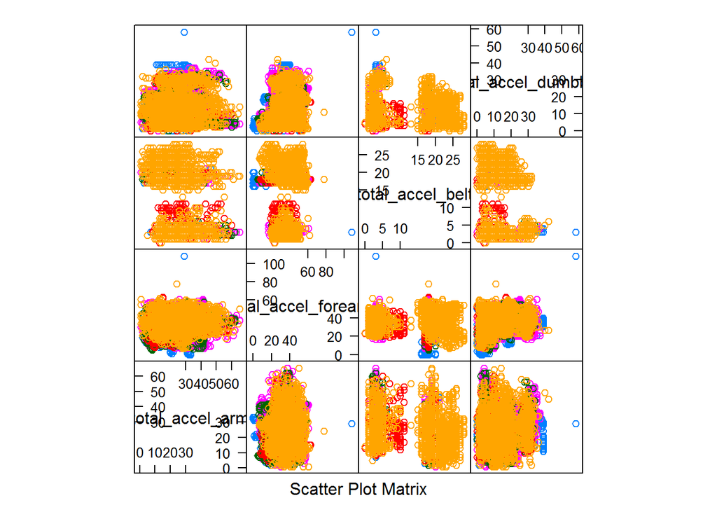

```r
featurePlot(x[, c("total_accel_arm", "total_accel_forearm", "total_accel_belt", "total_accel_dumbbell" )], classe, plot = "pairs")
```

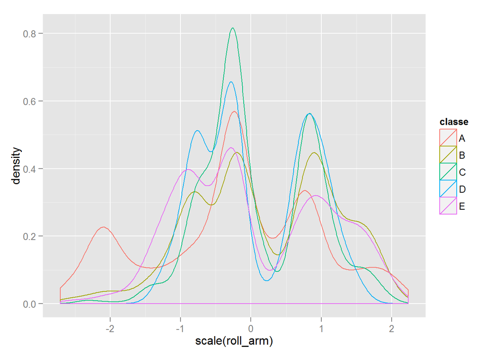

```r
qplot(scale(roll_arm), col = classe, geom = "density")
```

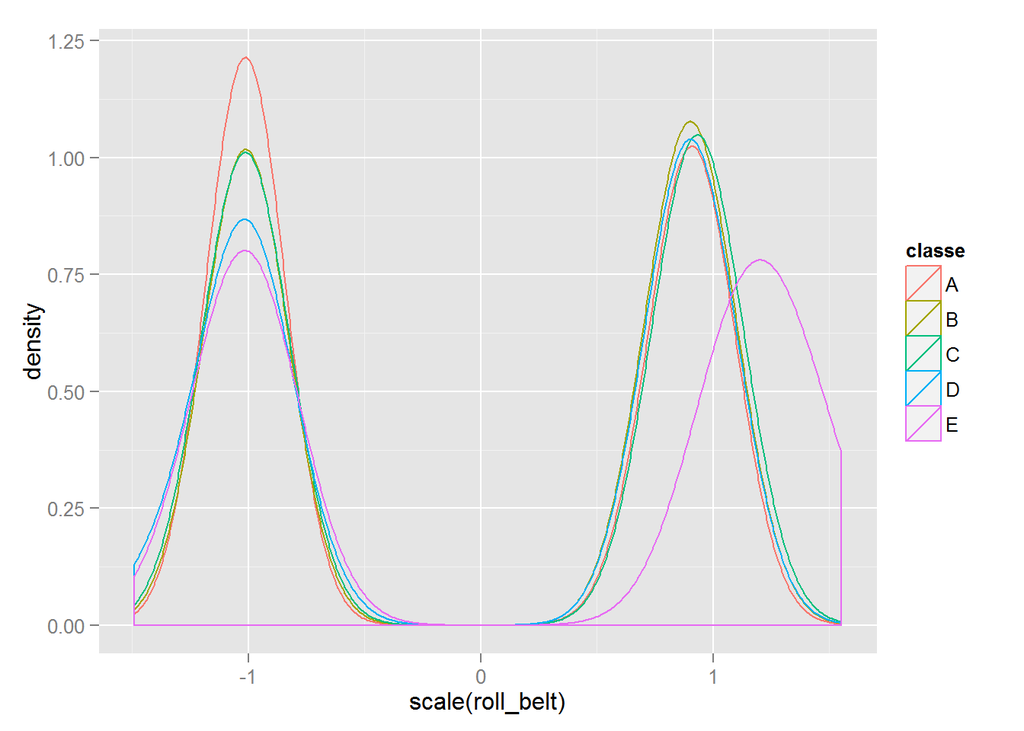

```r
qplot(scale(roll_belt), col = classe, geom = "density")
```

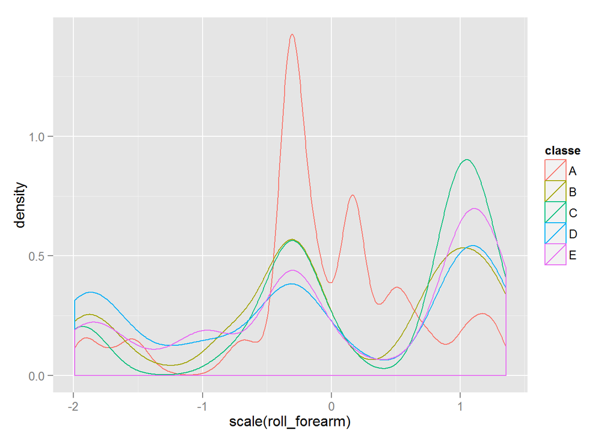

```r
qplot(scale(roll_forearm), col = classe, geom = "density")
```

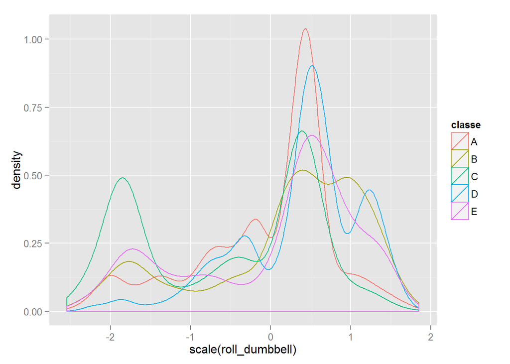

```r
qplot(scale(roll_dumbbell), col = classe, geom = "density")
```

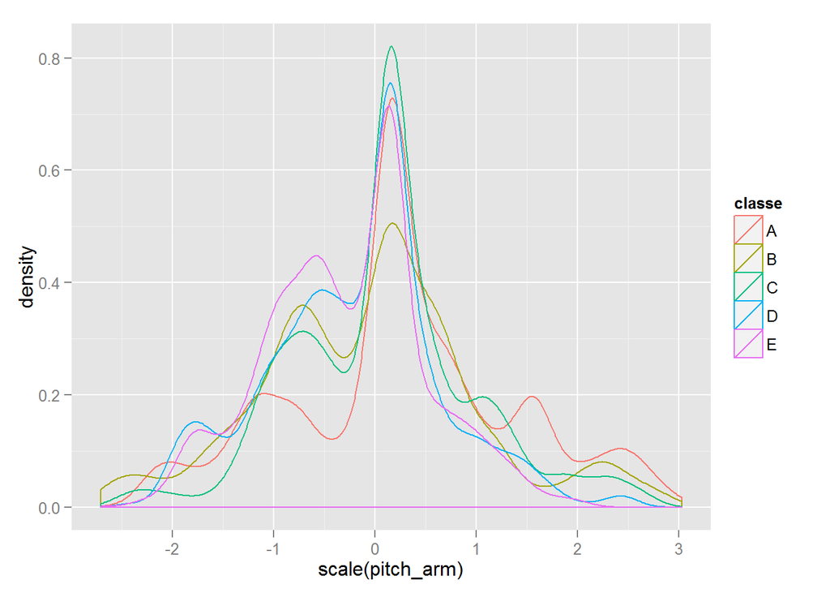

```r
qplot(scale(pitch_arm), col = classe, geom = "density")
```

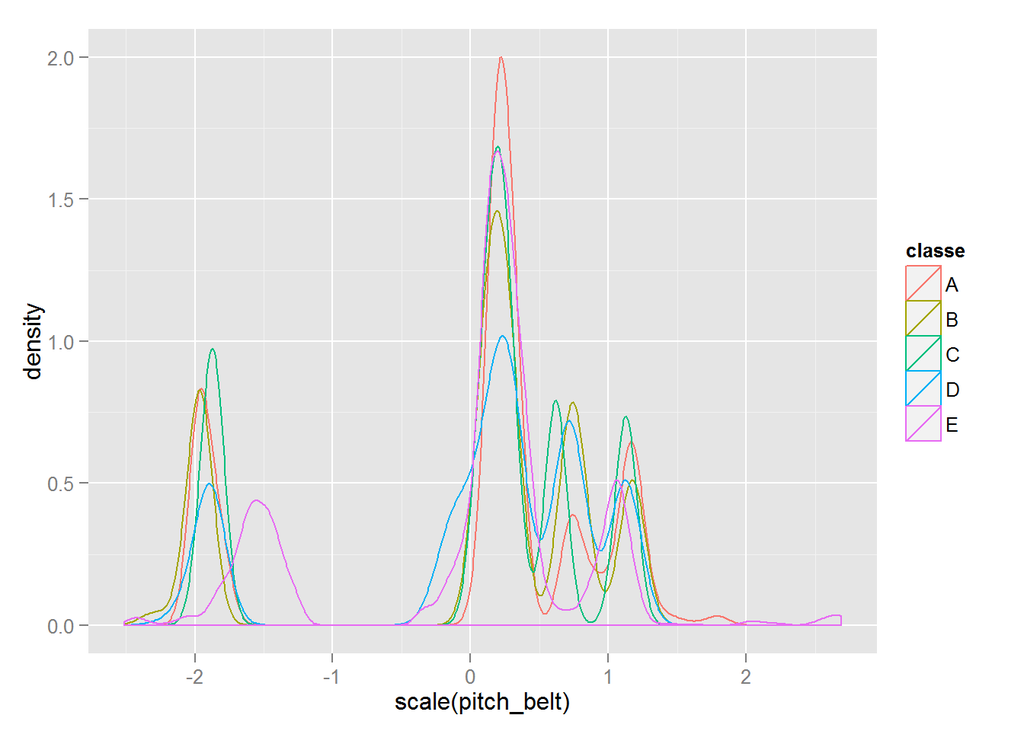

```r
qplot(scale(pitch_belt), col = classe, geom = "density")
```

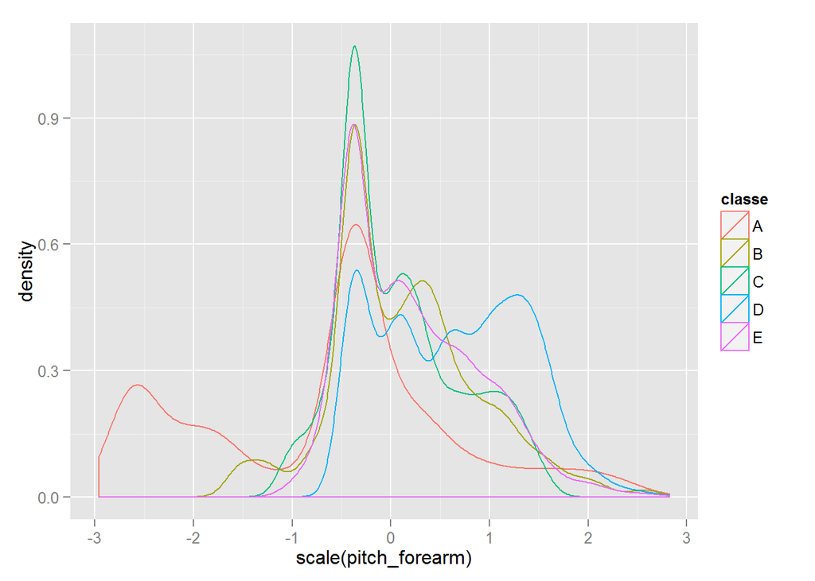

```r
qplot(scale(pitch_forearm), col = classe, geom = "density")
```

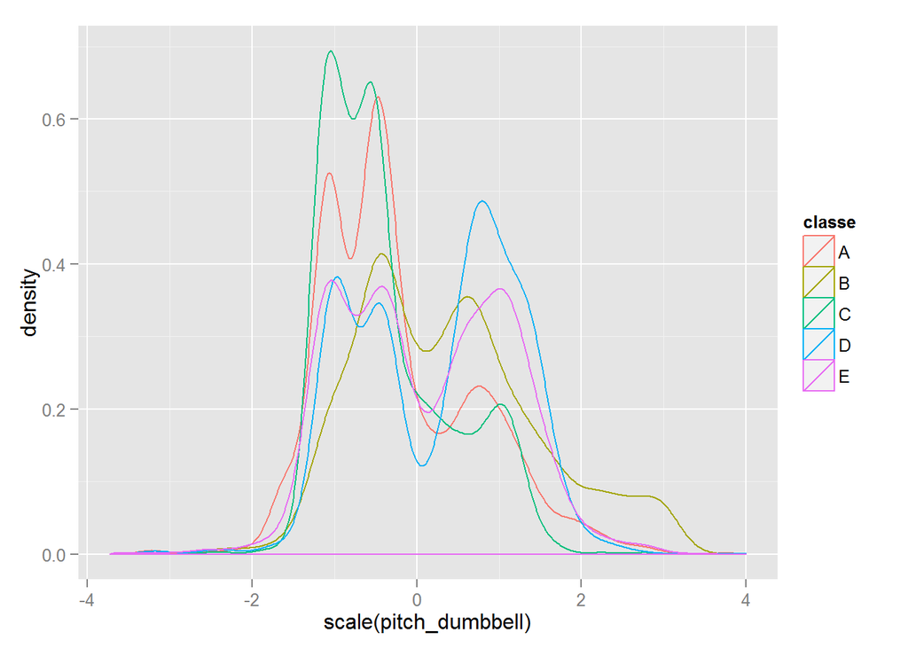

```r
qplot(scale(pitch_dumbbell), col = classe, geom = "density")
```

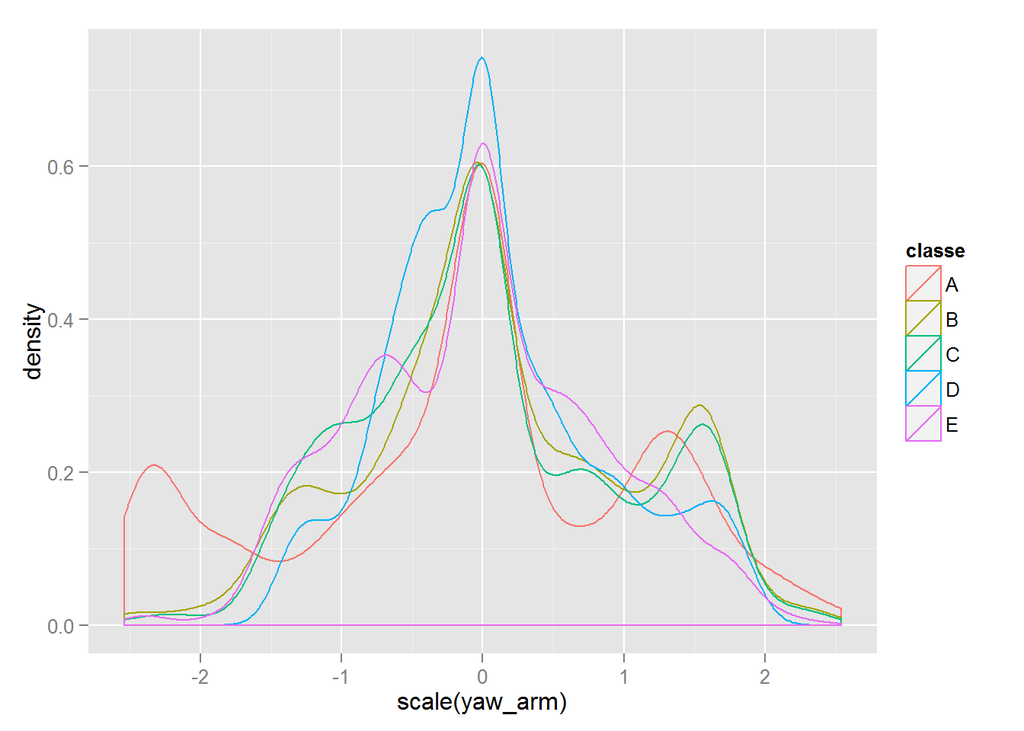

```r
qplot(scale(yaw_arm), col = classe, geom = "density")
```

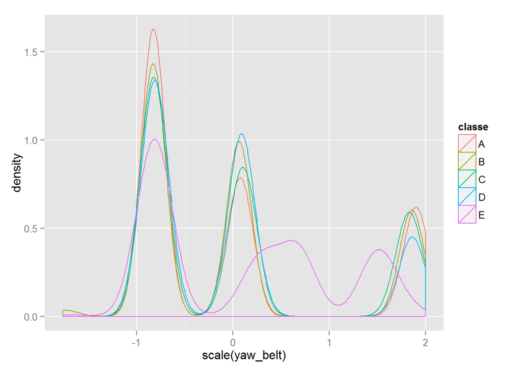

```r
qplot(scale(yaw_belt), col = classe, geom = "density")
```

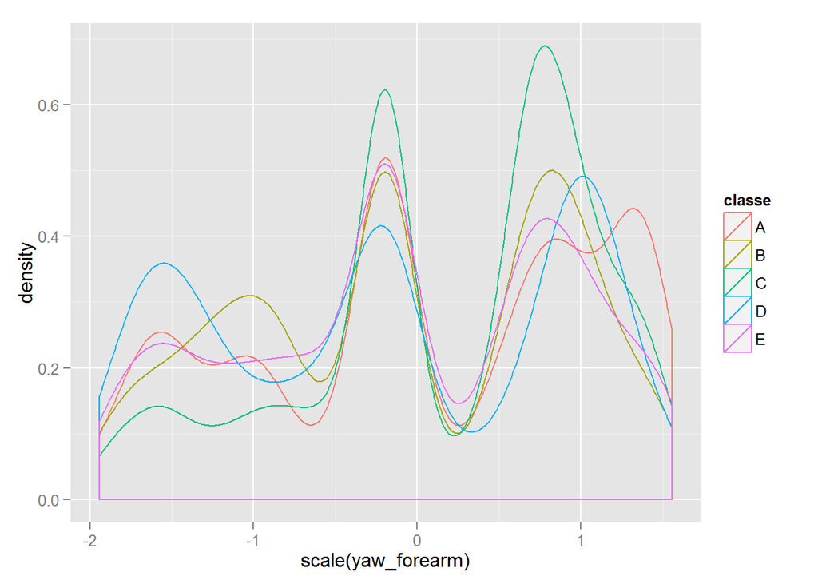

```r
qplot(scale(yaw_forearm), col = classe, geom = "density")
```

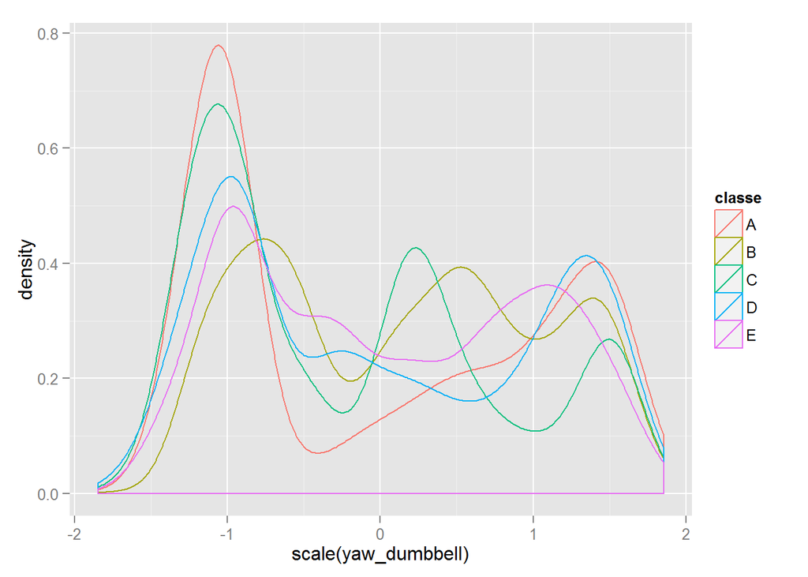

```r
qplot(scale(yaw_dumbbell), col = classe, geom = "density")
```

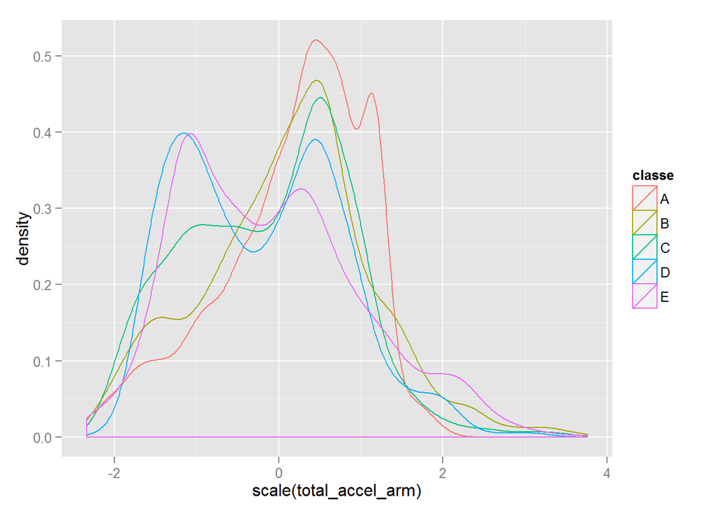

```r
qplot(scale(total_accel_arm), col = classe, geom = "density")
```

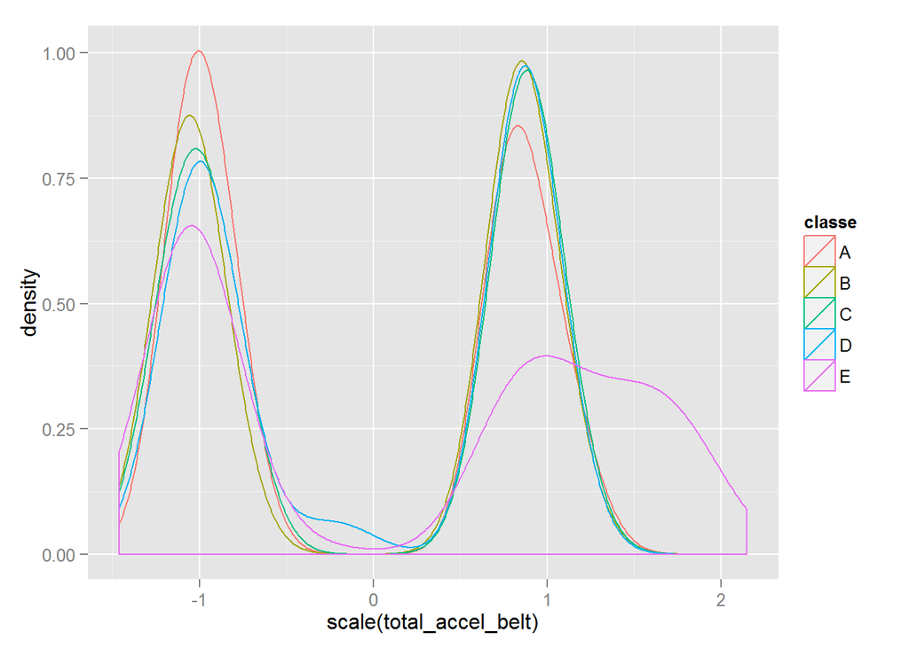

```r
qplot(scale(total_accel_belt), col = classe, geom = "density")
```

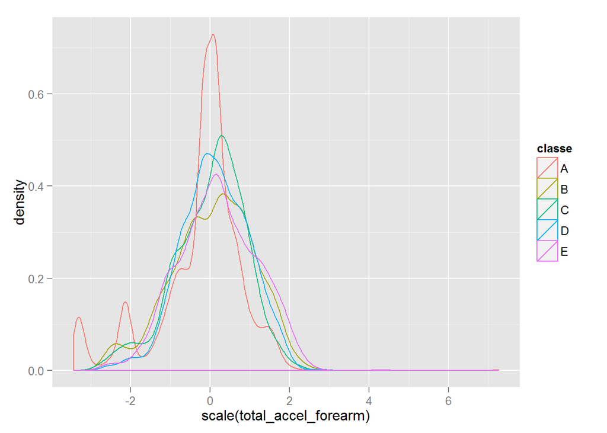

```r
qplot(scale(total_accel_forearm), col = classe, geom = "density")
```

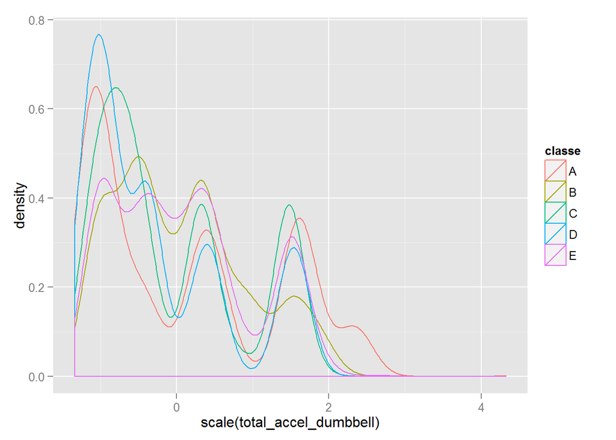

```r
qplot(scale(total_accel_dumbbell), col = classe, geom = "density")
```

```r
detach(x)
```